# Homework 6

Mark Chafin

3/16/2021

# 1

Import the data, show the structure of the dataset. Explain what variables in the dataset that are currently represented as quantitative variables but should be measured by nominal scale. Do not include those dummy variables.

```r
df <- read.csv("UniversalBank.csv", stringsAsFactors = TRUE)
str(df)
```

```
## 'data.frame':    5000 obs. of  14 variables:
##  $ Id                : int  1 2 3 4 5 6 7 8 9 10 ...
##  $ Age               : int  25 45 39 35 35 37 53 50 35 34 ...
##  $ Experience        : int  1 19 15 9 8 13 27 24 10 9 ...
##  $ Income            : int  49 34 11 100 45 29 72 22 81 180 ...
##  $ ZIP_Code          : int  91107 90089 94720 94112 91330 92121 91711 93943 90089 93023 ...
##  $ Family            : int  4 3 1 1 4 4 2 1 3 1 ...
##  $ CCAvg             : num  1.6 1.5 1 2.7 1 0.4 1.5 0.3 0.6 8.9 ...
##  $ Education         : int  1 1 1 2 2 2 2 3 2 3 ...
##  $ Mortgage          : int  0 0 0 0 0 155 0 0 104 0 ...
##  $ Personal_Loan     : int  0 0 0 0 0 0 0 0 0 1 ...
##  $ Securities_Account: int  1 1 0 0 0 0 0 0 0 0 ...
##  $ CD_Account        : int  0 0 0 0 0 0 0 0 0 0 ...
##  $ Online            : int  0 0 0 0 0 1 1 0 1 0 ...
##  $ CreditCard        : int  0 0 0 0 1 0 0 1 0 0 ...
```

# 2

Convert the data type of Education variable to dummies. Also remove the customer ID and zip code from the dataset.

```r
df$Education <- factor(df$Education, levels = c(1, 2, 3),
                       labels = c("Undergrad", "Graduate", "Advanced/Professional"))
df$Personal_Loan <- factor(df$Personal_Loan)
df <- select(df, -c(Id, ZIP_Code))
glimpse(df)
```

```
## Rows: 5,000
## Columns: 12
## $ Age                <int> 25, 45, 39, 35, 35, 37, 53, 50, 35, 34, 65, 29, 48,…
## $ Experience         <int> 1, 19, 15, 9, 8, 13, 27, 24, 10, 9, 39, 5, 23, 32, …
## $ Income             <int> 49, 34, 11, 100, 45, 29, 72, 22, 81, 180, 105, 45, …
## $ Family             <int> 4, 3, 1, 1, 4, 4, 2, 1, 3, 1, 4, 3, 2, 4, 1, 1, 4, …
## $ CCAvg              <dbl> 1.6, 1.5, 1.0, 2.7, 1.0, 0.4, 1.5, 0.3, 0.6, 8.9, 2…
## $ Education          <fct> Undergrad, Undergrad, Undergrad, Graduate, Graduate…
## $ Mortgage           <int> 0, 0, 0, 0, 0, 155, 0, 0, 104, 0, 0, 0, 0, 0, 0, 0,…
## $ Personal_Loan      <fct> 0, 0, 0, 0, 0, 0, 0, 0, 0, 1, 0, 0, 0, 0, 0, 0, 1, …
## $ Securities_Account <int> 1, 1, 0, 0, 0, 0, 0, 0, 0, 0, 0, 0, 1, 0, 1, 0, 0, …
## $ CD_Account         <int> 0, 0, 0, 0, 0, 0, 0, 0, 0, 0, 0, 0, 0, 0, 0, 0, 0, …
## $ Online             <int> 0, 0, 0, 0, 0, 1, 1, 0, 1, 0, 0, 1, 0, 1, 0, 1, 0, …
## $ CreditCard         <int> 0, 0, 0, 0, 1, 0, 0, 1, 0, 0, 0, 0, 0, 0, 0, 1, 0, …
```

# 3

Use logistic regression, LDA, and QDA to predict whether a customer accepts personal loan offered in the last campaign by Universal Bank. Use other variables remained in the dataset as predictors. Fit the machine learning models to the whole dataset (do not manually split the dataset into training and test sets) by using a 5-fold cross validation to calculate the performance measures including balanced accuracy, sensitivity, and specificity.

```r
fitControl <- trainControl(method = "cv", number = 5)

set.seed(100)



logit_fit <- train(factor(Personal_Loan) ~ ., data = df,trControl = fitControl, family = binomial(link = "logit"))




print(logit_fit)
```

```
## Random Forest
##
## 5000 samples
##   11 predictor
##    2 classes: '0', '1'
##
## No pre-processing
## Resampling: Cross-Validated (5 fold)
## Summary of sample sizes: 4000, 4000, 4000, 4000, 4000
## Resampling results across tuning parameters:
##
##   mtry  Accuracy  Kappa
##    2    0.9848    0.9057507
##    7    0.9892    0.9357038
##   12    0.9886    0.9322835
##
## Accuracy was used to select the optimal model using the largest value.
## The final value used for the model was mtry = 7.
```

```r
confusionMatrix(logit_fit)
```

```
## Cross-Validated (5 fold) Confusion Matrix
##
## (entries are percentual average cell counts across resamples)
##
##           Reference
## Prediction    0    1
##          0 90.2  0.8
##          1  0.2  8.8
##
##  Accuracy (average) : 0.9892
```

```r
k.folds <- function(k) {
  folds <- createFolds(df$Personal_Loan, k = k, list = TRUE, returnTrain = TRUE)
  accuracies <- c()

  for (i in 1:k) {
    model <- glm(Personal_Loan ~ ., data = df[folds[[i]],], family = binomial(link = 'logit'))

    pred_prob_cv <- predict(object = model, newdata = df[-folds[[i]],], type = "response")
    pred_class_cv <- ifelse(pred_prob_cv > 0.5, 1, 0)


    accuracies <- c(accuracies,
                    confusionMatrix(factor(pred_class_cv),
                                    df[-folds[[i]], ]$Personal_Loan, positive = "1")$byClass['Balanced Accuracy'])
  }
  accuracies
}

set.seed(100)
accuracies_cv <- k.folds(5)
accuracies_cv
```

```
## Balanced Accuracy Balanced Accuracy Balanced Accuracy Balanced Accuracy
##         0.8179388         0.8143897         0.8371128         0.8225940
## Balanced Accuracy
##         0.8667035
```

# logit // balanced accuracy

```r
# Calculate the average balanced accuracy
cat('Balanced Accuracy:\n Mean = ', mean(accuracies_cv),"; ",
    'Standard Deviation = ',sd(accuracies_cv), ";\n",
    '95% Confidence Interval = [',
    mean(accuracies_cv) - sd(accuracies_cv) * 1.96, ", ",
    mean(accuracies_cv) + sd(accuracies_cv) * 1.96,"]")
```

```
## Balanced Accuracy:
##  Mean =  0.8317478 ;  Standard Deviation =  0.02136861 ;
##  95% Confidence Interval = [ 0.7898653 ,  0.8736303 ]
```

# logit // sens // spec //accuracy

```r
## Train a logistic regression model with repeated 5-fold cross-validation
fitControl_rcv <- trainControl(method = "repeatedcv",
                               number = 5,
                               repeats = 200,
                               classProbs = TRUE,
                               summaryFunction = twoClassSummary)

set.seed(100)
logit_fit_rcv <- train(factor(ifelse(Personal_Loan==1, 'Yes', 'No'), levels = c('Yes','No')) ~ .,
                       data = df,
                       trControl = fitControl_rcv,
                       method="glm", family=binomial(link='logit'),
                       metric = "ROC")

print(logit_fit_rcv)
```

```
## Generalized Linear Model
##
## 5000 samples
##   11 predictor
##    2 classes: 'Yes', 'No'
##
## No pre-processing
## Resampling: Cross-Validated (5 fold, repeated 200 times)
## Summary of sample sizes: 4000, 4000, 4000, 4000, 4000, 4000, ...
## Resampling results:
##
##   ROC        Sens       Spec
##   0.9603877  0.6698229  0.9885033
```

```r
confusionMatrix(logit_fit_rcv)
```

```
## Cross-Validated (5 fold, repeated 200 times) Confusion Matrix
##
## (entries are percentual average cell counts across resamples)
##
##           Reference
## Prediction  Yes   No
##        Yes  6.4  1.0
##        No   3.2 89.4
##
##  Accuracy (average) : 0.9579
```

# Train LDA

```r
set.seed(100)
LDA_fit_rcv <- train(factor(ifelse(Personal_Loan==1, 'Yes', 'No'), levels = c('Yes','No')) ~ .,
                       data = df,
                       trControl = fitControl_rcv,
                       method="lda", family=binomial(link='logit'),
                       metric = "ROC")

print(LDA_fit_rcv)
```

```
## Linear Discriminant Analysis
##
## 5000 samples
##   11 predictor
##    2 classes: 'Yes', 'No'
##
## No pre-processing
## Resampling: Cross-Validated (5 fold, repeated 200 times)
## Summary of sample sizes: 4000, 4000, 4000, 4000, 4000, 4000, ...
## Resampling results:
##
##   ROC        Sens       Spec
##   0.9605344  0.6039167  0.9806383
```

```r
confusionMatrix(LDA_fit_rcv)
```

```
## Cross-Validated (5 fold, repeated 200 times) Confusion Matrix
##
## (entries are percentual average cell counts across resamples)
##
##           Reference
## Prediction  Yes   No
##        Yes  5.8  1.8
##        No   3.8 88.6
##
##  Accuracy (average) : 0.9445
```

## trying to get LDA balanced accuracy

```r
confusionMatrix(factor(predict(LDA_fit_rcv, newdata = df), levels = c("No", "Yes"),
                       labels = c("0", "1")),
                df$Personal_Loan, positive = '1')
```

```
## Confusion Matrix and Statistics
##
##           Reference
## Prediction    0    1
##          0 4435  184
##          1   85  296
##
##                Accuracy : 0.9462
##                  95% CI : (0.9396, 0.9523)
##     No Information Rate : 0.904
##     P-Value [Acc > NIR] : < 2.2e-16
##
##                   Kappa : 0.6586
##
##  Mcnemar's Test P-Value : 2.299e-09
##
##             Sensitivity : 0.6167
##             Specificity : 0.9812
##          Pos Pred Value : 0.7769
##          Neg Pred Value : 0.9602
##              Prevalence : 0.0960
##          Detection Rate : 0.0592
##    Detection Prevalence : 0.0762
##       Balanced Accuracy : 0.7989
##
##        'Positive' Class : 1
##
```

# Train QDA

```r
set.seed(100)
QDA_fit <- train(factor(ifelse(Personal_Loan==1, 'Yes', 'No'), levels = c('Yes','No')) ~ .,
                       data = df,
                       trControl = fitControl_rcv,
                       method="qda", family=binomial(link='logit'),
                       metric = "ROC")

print(QDA_fit)
```

```
## Quadratic Discriminant Analysis
##
## 5000 samples
##   11 predictor
##    2 classes: 'Yes', 'No'
##
## No pre-processing
## Resampling: Cross-Validated (5 fold, repeated 200 times)
## Summary of sample sizes: 4000, 4000, 4000, 4000, 4000, 4000, ...
## Resampling results:
##
##   ROC        Sens      Spec
##   0.9585961  0.662625  0.9598971
```

```r
confusionMatrix(QDA_fit)
```

```
## Cross-Validated (5 fold, repeated 200 times) Confusion Matrix
##
## (entries are percentual average cell counts across resamples)
##
##           Reference
## Prediction  Yes   No
##        Yes  6.4  3.6
##        No   3.2 86.8
##
##  Accuracy (average) : 0.9314
```

# QDA Stats

```r
confusionMatrix(factor(predict(QDA_fit, newdata = df), levels = c("No", "Yes"),
                       labels = c("0", "1")),
                df$Personal_Loan, positive = '1')
```

```
## Confusion Matrix and Statistics
##
##           Reference
## Prediction    0    1
##          0 4338  158
##          1  182  322
##
##                Accuracy : 0.932
##                  95% CI : (0.9247, 0.9388)
##     No Information Rate : 0.904
##     P-Value [Acc > NIR] : 1.082e-12
##
##                   Kappa : 0.6168
##
##  Mcnemar's Test P-Value : 0.2123
##
##             Sensitivity : 0.6708
##             Specificity : 0.9597
##          Pos Pred Value : 0.6389
##          Neg Pred Value : 0.9649
##              Prevalence : 0.0960
##          Detection Rate : 0.0644
##    Detection Prevalence : 0.1008
##       Balanced Accuracy : 0.8153
##
##        'Positive' Class : 1
##
```

#Bootstrap

```r
# Set the number of bootstraps
n_bootstraps <- 1000

# Initiate vectors of performance metric
bootstrap_acc_logit <- NULL
bootstrap_acc_lda <- NULL
bootstrap_acc_qda <- NULL

# Set the random number seed
set.seed(100)

for (i in 1:n_bootstraps){
  # Get a bootstrap of test dataset
  resample_test <- df[sample(nrow(df), replace = TRUE),]

  # Calculate predicted outcome
  logit_resample_pred <- predict(logit_fit_rcv, newdata = resample_test)
  #logit_resample_pred <- ifelse(logit_resample_prob > 0.5, 1, 0)

  lda_resample_pred <- predict(LDA_fit_rcv, newdata = resample_test)
  qda_resample_pred <- predict(QDA_fit, newdata = resample_test)

  # Calculate accuracy of the logit model using the bootstrap
  bootstrap_acc_logit <- c(bootstrap_acc_logit, mean(logit_resample_pred == factor(ifelse(resample_test$Personal_Loan==1, 'Yes', 'No'), levels = c('Yes','No'))))

  # Calculate f1 score of the logit model using the bootstrap
  bootstrap_acc_lda <- c(bootstrap_acc_lda, mean(lda_resample_pred == factor(ifelse(resample_test$Personal_Loan==1, 'Yes', 'No'), levels = c('Yes','No'))))

  bootstrap_acc_qda <- c(bootstrap_acc_qda, mean(qda_resample_pred == factor(ifelse(resample_test$Personal_Loan==1, 'Yes', 'No'), levels = c('Yes','No'))))
}
```

```r
summary(bootstrap_acc_logit)
```

```
##    Min. 1st Qu.  Median    Mean 3rd Qu.    Max.
##  0.9482  0.9572  0.9592  0.9591  0.9610  0.9682
```

```r
summary(bootstrap_acc_lda)
```

```
##    Min. 1st Qu.  Median    Mean 3rd Qu.    Max.
##  0.9354  0.9442  0.9464  0.9463  0.9484  0.9556
```

```r
summary(bootstrap_acc_qda)
```

```
##    Min. 1st Qu.  Median    Mean 3rd Qu.    Max.
##  0.9206  0.9294  0.9320  0.9320  0.9344  0.9444
```

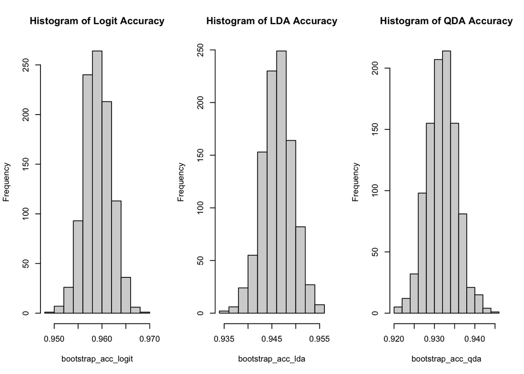

```r
# Plot the accuracy

par(mfrow=c(1,3))

hist(bootstrap_acc_logit,main = "Histogram of Logit Accuracy")
hist(bootstrap_acc_lda, main = "Histogram of LDA Accuracy")
hist(bootstrap_acc_qda, main = "Histogram of QDA Accuracy")
```

```r
cat("95% CI of Logit = ",
    "(",
    quantile(bootstrap_acc_logit, 0.025),
    ", ",
    quantile(bootstrap_acc_logit, 0.975),
    ")")
```

```
## 95% CI of Logit =  ( 0.9536 ,  0.964405 )
```

```r
cat("95% CI of LDA = ",
    "(",
    quantile(bootstrap_acc_lda, 0.025),
    ", ",
    quantile(bootstrap_acc_lda, 0.975),
    ")")
```

```
## 95% CI of LDA =  ( 0.9398 ,  0.9526 )
```

```r
cat("95% CI of QDA = ",
    "(",
    quantile(bootstrap_acc_qda, 0.025),
    ", ",
    quantile(bootstrap_acc_qda, 0.975),
    ")")
```

```
## 95% CI of QDA =  ( 0.9246 ,  0.93921 )
```

```r
cat("95% CI of Logit (normal approximation) = ",
    "(",
    mean(bootstrap_acc_logit)-1.96*sd(bootstrap_acc_logit),
    ", ",
    mean(bootstrap_acc_logit)+1.96*sd(bootstrap_acc_logit),
    ")")
```

```
## 95% CI of Logit (normal approximation) =  ( 0.9536155 ,  0.9646689 )
```

```r
cat("95% CI of LDA (normal approximation) = ",
    "(",
    mean(bootstrap_acc_lda, 0.025)-1.96*sd(bootstrap_acc_lda),
    ", ",
    mean(bootstrap_acc_lda, 0.025)+1.96*sd(bootstrap_acc_lda),
    ")")
```

```
## 95% CI of LDA (normal approximation) =  ( 0.9399907 ,  0.9525735 )
```

```r
cat("95% CI of QDA (normal approximation) = ",
    "(",
    mean(bootstrap_acc_qda, 0.025)-1.96*sd(bootstrap_acc_qda),
    ", ",
    mean(bootstrap_acc_qda, 0.025)+1.96*sd(bootstrap_acc_qda),
    ")")
```

```
## 95% CI of QDA (normal approximation) =  ( 0.9247926 ,  0.9390865 )
```

```r
End_time <- Sys.time()
End_time - Start_time
```

```
## Time difference of 3.478316 mins
```

## 4

Logistic regression performs better compared to LDA and QDA when predicting if a personal loan will be accepted using balanced accuracy. Logistic Regression was slightly higher with balanced accuracy while LDA and QDA were both lower. Balanced was much closer compared to using sensitivity.